# Xác định năm có dịch - Lần 2

```r
library(tidyverse)
library(MASS)      # Negative Binomial
library(mgcv)      # GAM
library(forecast)  # SARIMA
library(gt)
library(patchwork)
library(googlesheets4)
library(googledrive)

# Hàm xử lý dữ liệu đầu vào thành chuỗi thời gian liên tục 520 tuần
prep_continuous_ts <- function(df_cases, disease_name) {
  df_cases %>%
    pivot_longer(cols = -Week, names_to = "Year", values_to = "Cases") %>%
    mutate(
      Year = as.numeric(Year),
      Disease = disease_name
    ) %>%
    filter(Year != 2026) %>%
    arrange(Year, Week) %>%
    # BƯỚC QUAN TRỌNG CHUẨN BỊ CHO TIME-SERIES:
    mutate(
      Time_Index = row_number(), # Trục t chạy liên tục từ 1 -> 520
      # Giả lập cột Date (Ngày đầu tiên của tuần) để mớm cho Prophet
      Date = as.Date(paste0(Year, "-01-01")) + (Week - 1) * 7
    ) %>%
    # Bọc lót loại bỏ hoàn toàn NA để mô hình không báo lỗi
    mutate(Cases = replace_na(Cases, 0))
}

theme_hcdc_report <- function() {
  theme_bw(base_size = 14) +
    theme(
      text = element_text(color = "black"),
      axis.text = element_text(color = "black", size = 12),
      axis.title = element_text(color = "black", size = 14, face = "bold"),
      plot.title = element_text(color = "black", size = 16, face = "bold", hjust = 0.5),
      plot.subtitle = element_text(color = "black", size = 13, hjust = 0.5, margin = margin(b = 10)),
      legend.text = element_text(color = "black", size = 12),
      legend.title = element_text(color = "black", size = 12, face = "bold"),
      panel.grid.minor = element_blank(),
      panel.grid.major = element_line(color = "gray85", linetype = "dashed"),
      plot.background = element_rect(fill = "white", color = NA),
      panel.background = element_rect(fill = "white", color = NA),
      strip.text = element_text(color = "white", size = 14, face = "bold"),
      strip.background = element_rect(fill = "#1D3557", color = NA)
    )
}

load_data <- function(url, sheet) {
  gs4_deauth()
  df <- read_sheet(url, sheet = sheet)
  return(df)
}

sxh_cases <- load_data("https://docs.google.com/spreadsheets/d/13_o7NAlfBjckO6PspzITbWhlkWbfp4eKkqYCa7Dvvgg/edit?usp=sharing", "ca")

tcm_cases <- load_data("https://docs.google.com/spreadsheets/d/1jSAuGFUkcHBL5iie999qn7ClW2dTYB3AOSOaRwOBCGY/edit?usp=sharing", "ca")

df_ts_sxh <- prep_continuous_ts(sxh_cases, "Dengue")
df_ts_tcm <- prep_continuous_ts(tcm_cases, "HFMD")
df_ts_all <- bind_rows(df_ts_sxh, df_ts_tcm)
```

## Các mô hình time-series

### Mô hình Hồi quy Nhị thức âm (Negative Binomial Regression - NB)

Trong dịch tễ học, dữ liệu số ca mắc theo tuần là dữ liệu dạng đếm. Mô hình Poisson thường được sử dụng, nhưng bị ràng buộc bởi giả định phương sai phải bằng giá trị trung bình. Thực tế, các bệnh truyền nhiễm này có hiện tượng phân tán quá mức, tức là phương sai lớn hơn rất nhiều so với trung bình. Do đó, mô hình Negative Binomial (NB) được sử dụng để khắc phục nhược điểm này bằng cách bổ sung một tham số phân tán giúp mô hình linh hoạt hơn.

Mô hình NB dự đoán giá trị kỳ vọng của số ca mắc $\mu_t = E[Y_t]$ tại thời điểm $t$ thông qua hàm liên kết logarit:

$$\log(\mu_t) = \beta_0 + \beta_1 \cdot \text{Time\_Index}_t + \sum_{k=1}^{51} \gamma_k \cdot I(\text{Week}_t = k)$$

Trong đó:

- $Y_t$: Số ca mắc thực tế tại tuần
- $t$.$\text{Time\_Index}_t$: Biến thời gian tuyến tính đại diện cho xu hướng dài hạn.
- $I(\text{Week}_t = k)$: Biến giả (dummy variable) đại diện cho tính mùa vụ, nhận giá trị $1$ nếu tuần $t$ rơi vào tuần thứ $k$ trong năm, ngược lại bằng $0$.
- Phương sai của mô hình được định nghĩa là: $Var(Y_t) = \mu_t + \frac{\mu_t^2}{\theta}$ (với $\theta$ là tham số phân tán).

### Mô hình Generalized Additive Model (GAM):

Trong khi hồi quy tuyến tính truyền thống giả định mối quan hệ giữa các biến là một đường thẳng hoặc một hình thái cố định, GAM mô hình hóa các mối quan hệ phi tuyến tính (non-linear). GAM thay thế các hệ số hồi quy cố định bằng các hàm làm mượt nên sẽ có dạng đường cong. Trong dịch tễ học khi xu hướng dài hạn của bệnh không tăng hay giảm theo đường thẳng, mà sẽ dao động theo chu kỳ của bệnh.

Mô hình GAM cho dữ liệu chuỗi thời gian đếm (sử dụng phân phối Negative Binomial):

$$\log(\mu_t) = \beta_0 + f_1(\text{Time\_Index}_t) + f_2(\text{Week}_t)$$

### Mô hình phân rã chuỗi thời gian Robust STL

STL (Seasonal and Trend decomposition using Loess) là một thuật toán phân rã chuỗi thời gian sử dụng phương pháp hồi quy LOESS để bóc tách dữ liệu thành 3 phần: Xu hướng (Trend), Mùa vụ (Seasonality) và Phần dư (Remainder). Thuật toán này có tính năng kiểm soát nhiễu (Robustness), tự động phát hiện các giá trị outliers và hạ thấp weights xuống gần bằng 0, giúp các đợt dịch lớn không thể ảnh hưởng đến Expected cases.

Dữ liệu gốc $Y_t$ được phân rã cộng tính:
$$Y_t = T_t + S_t + R_t$$

- $T_t$: Thành phần xu hướng dài hạn (Trend).
- $S_t$: Thành phần mùa vụ (Seasonality).
- $R_t$: Thành phần phần dư (Remainder). Đường cơ sở kỳ vọng (Expected Baseline) được trích xuất bằng cách loại bỏ phần dư:
  $$\text{Expected}_t = Y_t - R_t = T_t + S_t$$

**Các bước tính toán:**

- Tính $S_t$ của từng tuần bằng trung bình cộng của các năm.
- Tính $T_t$ sơ khởi: $Y_t - S_t$ để tìm ra $T_t$ năm bất thường.
- Tính $T_t$ hiệu chỉnh của năm bất thường bằng hồi quy LOESS của 3 năm (bao gồm năm bất thường là ở giữa và năm trước, năm sau của năm bất thường đó). Tiếp theo sẽ gán trọng số cho từng năm, năm giữa có trọng số cao nhất. $T_t$ hiệu chỉnh của năm bất thường được tính bằng trung bình cộng có trọng số của $T_t$ sơ khởi của 3 năm.
- Tính phần dư $R_t = Y_t - T_t - S_t$.
- Gán trọng số w = 0 cho những năm có $|R_t| >= 6*Median(|R_t|)$, ngược lại thì có w = 1.
- Lặp lại từ bước tính $S_t$, bỏ qua những năm có w = 0, sẽ có $S_n$ và $T_n$. Cuối cùng sẽ tính ra được
  $$\text{Expected} = T_{\text{new}} + S_{\text{new}}$$
  .

```r
run_advanced_multimodel <- function(df) {
  diseases <- unique(df$Disease)
  eval_results <- list()
  fitted_results <- list()

  for (dis in diseases) {
    df_dis <- df %>% filter(Disease == dis)
    start_wk <- ifelse(dis == "Dengue", 15, 1)

    # 1. FIT MÔ HÌNH
    nb_mod <- tryCatch(glm.nb(Cases ~ as.factor(Week) + Time_Index, data = df_dis), error=function(e) NULL)
    fit_nb <- if(!is.null(nb_mod)) predict(nb_mod, newdata = df_dis, type = "response") else rep(NA, nrow(df_dis))

    gam_mod <- gam(Cases ~ s(Time_Index) + s(Week, bs = "cc"), family = nb(), data = df_dis)
    fit_gam <- as.numeric(fitted(gam_mod))

    ts_cases <- ts(df_dis$Cases, frequency = 52)
    stl_mod <- stl(ts_cases, s.window = "periodic", robust = TRUE)
    fit_stl <- as.numeric(ts_cases - stl_mod$time.series[, "remainder"])

    df_fitted <- df_dis %>%
      mutate(Fit_GAM = fit_gam, Fit_NB = fit_nb, Fit_STL = fit_stl) %>%
      mutate(across(starts_with("Fit_"), ~ ifelse(.x < 0, 0, .x))) %>%
      mutate(Epi_Year = ifelse(Week < start_wk, Year - 1, Year)) %>%
      pivot_longer(cols = starts_with("Fit_"), names_to = "Model", names_prefix = "Fit_", values_to = "Expected")

    df_eval <- df_fitted %>%
      filter(Epi_Year >= min(df_dis$Year) & Epi_Year < max(df_dis$Year)) %>%
      group_by(Epi_Year, Model) %>%
      summarise(
        RMSE = sqrt(mean((Cases - Expected)^2, na.rm = TRUE)),
        Log_RMSE = sqrt(mean((log1p(Cases) - log1p(Expected))^2, na.rm = TRUE)),
        sMAPE = mean(2 * abs(Cases - Expected) / (abs(Cases) + abs(Expected) + 1e-8), na.rm = TRUE),
        P_Value = suppressWarnings(wilcox.test(Cases, Expected, paired = TRUE, exact = FALSE)$p.value),
        Sum_Act = sum(Cases, na.rm = TRUE),
        Sum_Fit = sum(Expected, na.rm = TRUE),
        .groups = "drop"
      ) %>%
      group_by(Model) %>%
      mutate(
        Base_RMSE = median(RMSE, na.rm = TRUE),
        Base_Log = median(Log_RMSE, na.rm = TRUE),
        Base_sMAPE = median(sMAPE, na.rm = TRUE),

        # Dán nhãn riêng cho RMSE
        Trig_RMSE = (RMSE > 1.5 * Base_RMSE) & (P_Value < 0.05),
        St_RMSE = case_when(Trig_RMSE & (Sum_Act > Sum_Fit) ~ "High", Trig_RMSE & (Sum_Act < Sum_Fit) ~ "Low", TRUE ~ "-"),

        # Dán nhãn riêng cho Log-RMSE
        Trig_Log = (Log_RMSE > 1.5 * Base_Log) & (P_Value < 0.05),
        St_Log = case_when(Trig_Log & (Sum_Act > Sum_Fit) ~ "High", Trig_Log & (Sum_Act < Sum_Fit) ~ "Low", TRUE ~ "-"),

        # Dán nhãn riêng cho sMAPE
        Trig_sMAPE = (sMAPE > 1.5 * Base_sMAPE) & (P_Value < 0.05),
        St_sMAPE = case_when(Trig_sMAPE & (Sum_Act > Sum_Fit) ~ "High", Trig_sMAPE & (Sum_Act < Sum_Fit) ~ "Low", TRUE ~ "-"),

        Plot_Status = case_when(
          (St_RMSE == "High" | St_Log == "High" | St_sMAPE == "High") ~ "Abnormal (High)",
          (St_RMSE == "Low" | St_Log == "Low" | St_sMAPE == "Low") ~ "Abnormal (Low)",
          TRUE ~ "Normal"
        )
      ) %>%
      ungroup() %>%
      mutate(Disease = dis)

    eval_results[[dis]] <- df_eval

    fitted_results[[dis]] <- df_fitted %>%
      left_join(df_eval %>% dplyr::select(Epi_Year, Model, Plot_Status), by = c("Epi_Year", "Model")) %>%
      mutate(Plot_Status = replace_na(Plot_Status, "Normal"))
  }

  return(list(eval = bind_rows(eval_results), plot_data = bind_rows(fitted_results)))
}


create_mega_table <- function(eval_df, target_disease) {
  df_sub <- eval_df %>%
    filter(Disease == target_disease) %>%
    mutate(Epi_Label = ifelse(Disease == "Dengue", paste0(Epi_Year, "-", Epi_Year + 1), as.character(Epi_Year))) %>%
    dplyr::select(Epi_Label, Model, RMSE, St_RMSE, Log_RMSE, St_Log, sMAPE, St_sMAPE, P_Value)

  wide_df <- df_sub %>%
    pivot_wider(
      names_from = Model,
      values_from = c(RMSE, St_RMSE, Log_RMSE, St_Log, sMAPE, St_sMAPE, P_Value),
      names_glue = "{.value}_{Model}"
    )

  tbl <- wide_df %>%
    gt() %>%
    tab_header(
      title = md(sprintf("**%s**", target_disease))
    ) %>%

    fmt_number(columns = starts_with("RMSE_"), decimals = 0) %>%
    fmt_number(columns = starts_with("Log_RMSE_"), decimals = 3) %>%
    fmt_number(columns = starts_with("sMAPE_"), decimals = 3) %>%
    fmt_number(columns = starts_with("P_Value_"), decimals = 4) %>%

    tab_spanner(label = md("**GAM Model**"), columns = ends_with("_GAM")) %>%
    tab_spanner(label = md("**NB Model**"), columns = ends_with("_NB")) %>%
    tab_spanner(label = md("**STL (Robust)**"), columns = ends_with("_STL")) %>%

    cols_label(
      Epi_Label = "Epi-Year",
      RMSE_GAM = "RMSE", St_RMSE_GAM = "St", Log_RMSE_GAM = "Log", St_Log_GAM = "St", sMAPE_GAM = "sMAPE", St_sMAPE_GAM = "St", P_Value_GAM = "P-val",
      RMSE_NB = "RMSE", St_RMSE_NB = "St", Log_RMSE_NB = "Log", St_Log_NB = "St", sMAPE_NB = "sMAPE", St_sMAPE_NB = "St", P_Value_NB = "P-val",
      RMSE_STL = "RMSE", St_RMSE_STL = "St", Log_RMSE_STL = "Log", St_Log_STL = "St", sMAPE_STL = "sMAPE", St_sMAPE_STL = "St", P_Value_STL = "P-val"
    ) %>%
    cols_align(align = "center", columns = starts_with("St_"))

  status_cols <- names(wide_df)[str_detect(names(wide_df), "^St_")]

  for (col in status_cols) {
    tbl <- tbl %>%
      tab_style(
        style = list(cell_fill(color = "#fee2e2"), cell_text(color = "#b91c1c", weight = "bold")),
        locations = cells_body(columns = all_of(col), rows = .data[[col]] == "High")
      ) %>%
      tab_style(
        style = list(cell_fill(color = "#fef08a"), cell_text(color = "#b45309", weight = "bold")),
        locations = cells_body(columns = all_of(col), rows = .data[[col]] == "Low")
      )
  }

  return(tbl)
}


plot_elite_timeseries <- function(plot_df, disease_target) {
  df_target <- plot_df %>% filter(Disease == disease_target)

  year_breaks <- df_target %>% filter(Week == 1) %>% pull(Time_Index)
  year_labels <- df_target %>% filter(Week == 1) %>% pull(Year)

  p <- ggplot(df_target, aes(x = Time_Index)) +
    # RED ZONE (High Outbreaks)
    geom_rect(
      data = df_target %>% filter(Plot_Status == "Abnormal (High)"),
      aes(xmin = Time_Index - 0.5, xmax = Time_Index + 0.5, ymin = 0, ymax = Inf),
      fill = "#fee2e2", alpha = 0.4, inherit.aes = FALSE
    ) +
    # YELLOW ZONE (Suppressed Years)
    geom_rect(
      data = df_target %>% filter(Plot_Status == "Abnormal (Low)"),
      aes(xmin = Time_Index - 0.5, xmax = Time_Index + 0.5, ymin = 0, ymax = Inf),
      fill = "#fef08a", alpha = 0.4, inherit.aes = FALSE
    ) +
    geom_line(aes(y = Cases), color = "#94a3b8", alpha = 0.5, linewidth = 0.8) +
    geom_line(aes(y = Expected, color = Model), linewidth = 1) +
    facet_wrap(~ Model, ncol = 1) +
    scale_x_continuous(breaks = year_breaks, labels = year_labels) +
    scale_color_manual(values = c("GAM" = "#2563eb", "NB" = "#16a34a", "STL" = "#d97706")) +
    labs(
      title = paste("Continuous Time-Series Analysis:", disease_target, "(2016 - 2025)"),
      subtitle = "Grey line: Actual | Colored: Expected | Red: Abnormal High | Yellow: Abnormal Low",
      x = "Timeline (Years)",
      y = "Epidemiological Cases"
    ) +
    theme_hcdc_report() +
    theme(
      legend.position = "none",
      panel.grid.major.x = element_line(color = "black", linetype = "dashed", alpha = 0.3),
      strip.background = element_rect(fill = "#1D3557"),
      strip.text = element_text(color = "white", face = "bold")
    )

  return(p)
}
```

```r
res_m2 <- run_advanced_multimodel(df_ts_all)
```

```r
create_mega_table(res_m2$eval, "Dengue")
```

**Dengue**

| Epi-Year | **GAM Model** RMSE | **GAM Model** St | **GAM Model** Log | **GAM Model** St | **GAM Model** sMAPE | **GAM Model** St | **GAM Model** P-val | **NB Model** RMSE | **NB Model** St | **NB Model** Log | **NB Model** St | **NB Model** sMAPE | **NB Model** St | **NB Model** P-val | **STL (Robust)** RMSE | **STL (Robust)** St | **STL (Robust)** Log | **STL (Robust)** St | **STL (Robust)** sMAPE | **STL (Robust)** St | **STL (Robust)** P-val |
| --- | --- | --- | --- | --- | --- | --- | --- | --- | --- | --- | --- | --- | --- | --- | --- | --- | --- | --- | --- | --- | --- |
| 2016-2017 | 209 | - | 0.442 | - | 0.321 | - | 0.0003 | 529 | - | 0.766 | - | 0.526 | - | 0.0000 | 118 | - | 0.287 | - | 0.203 | - | 0.0002 |
| 2017-2018 | 290 | - | 0.323 | - | 0.294 | - | 0.5569 | 220 | - | 0.228 | - | 0.172 | - | 0.0313 | 300 | - | 0.306 | - | 0.255 | - | 0.3143 |
| 2018-2019 | 414 | - | 0.308 | - | 0.262 | - | 0.1389 | 736 | - | 0.575 | - | 0.460 | - | 0.0004 | 563 | High | 0.367 | - | 0.297 | - | 0.0002 |
| 2019-2020 | 439 | - | 0.402 | - | 0.317 | - | 0.8519 | 750 | - | 0.469 | - | 0.401 | - | 0.0000 | 906 | High | 0.573 | High | 0.477 | High | 0.0002 |
| 2020-2021 | 289 | - | 0.548 | - | 0.475 | - | 0.0508 | 420 | - | 0.639 | - | 0.464 | - | 0.0000 | 108 | - | 0.268 | - | 0.196 | - | 0.6326 |
| 2021-2022 | 704 | Low | 1.168 | Low | 0.856 | Low | 0.0000 | 778 | - | 1.241 | Low | 0.791 | Low | 0.0000 | 308 | - | 0.821 | Low | 0.584 | Low | 0.0022 |
| 2022-2023 | 1,259 | High | 0.529 | - | 0.438 | - | 0.0141 | 1,732 | High | 0.841 | - | 0.602 | - | 0.0000 | 1,980 | High | 1.068 | High | 0.690 | High | 0.0000 |
| 2023-2024 | 137 | - | 0.334 | - | 0.262 | - | 0.2887 | 635 | - | 0.928 | - | 0.815 | Low | 0.0000 | 110 | - | 0.306 | - | 0.212 | - | 0.0060 |
| 2024-2025 | 93 | - | 0.203 | - | 0.166 | - | 0.8164 | 579 | - | 0.844 | - | 0.645 | - | 0.0000 | 135 | - | 0.826 | - | 0.369 | - | 0.0765 |

- Tính RMSE của từng năm

$RMSE = \sqrt{\frac{1}{52} \sum_{i=1}^{52} (\text{Cases}_i - \text{Expected}_i)^2}$

Dengue năm 2022 có số ca tăng quá lớn, các mô hình như GAM, NB sẽ bị năm 2022 này kéo xệch toàn bộ đường Expected cases của 10 năm và tăng phương sai của mô hình. Do đó, đợt bùng phát của 2018-2019, 2019-2020 được xem là bình thường. Ngược lại mô hình STL trượt dọc theo chuỗi thời gian liên tục và linh hoạt tách tính xu hướng ra khỏi tính mùa vụ, nên năm 2022 sẽ không ảnh hưởng nhiều đến toàn bộ đường Expected cases của 10 năm, dẫn đến kết quả phát hiện được các năm bất thường 2018-2019, 2019-2020.

Do đó, để cân bằng sai số giữa trường hợp tăng từ 1.000 lên 10.000 hay giảm từ 1.000 xuống 100 thì nhóm đánh giá thêm Log-RMSE và sMAPE Symmetric Mean Absolute Percentage Error. Kết hợp 3 chỉ số để đánh giá xem một năm là năm bất thường (số ca quá cao hay là số ca quá thấp).

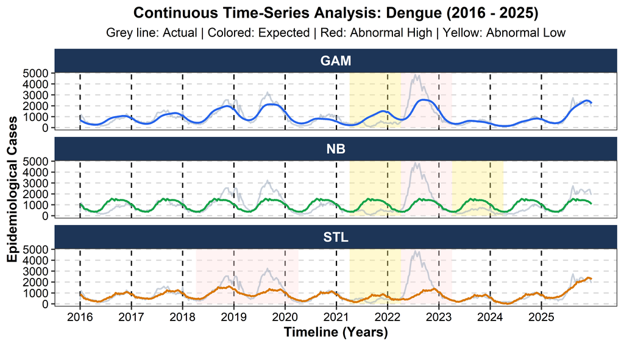

```r
plot_elite_timeseries(res_m2$plot_data, "Dengue")
```

```r
create_mega_table(res_m2$eval, "HFMD")
```

**HFMD**

| Epi-Year | **GAM Model** RMSE | **GAM Model** St | **GAM Model** Log | **GAM Model** St | **GAM Model** sMAPE | **GAM Model** St | **GAM Model** P-val | **NB Model** RMSE | **NB Model** St | **NB Model** Log | **NB Model** St | **NB Model** sMAPE | **NB Model** St | **NB Model** P-val | **STL (Robust)** RMSE | **STL (Robust)** St | **STL (Robust)** Log | **STL (Robust)** St | **STL (Robust)** sMAPE | **STL (Robust)** St | **STL (Robust)** P-val |
| --- | --- | --- | --- | --- | --- | --- | --- | --- | --- | --- | --- | --- | --- | --- | --- | --- | --- | --- | --- | --- | --- |
| 2016 | 137 | - | 0.694 | - | 0.582 | - | 0.0000 | 443 | - | 1.387 | Low | 1.106 | Low | 0.0000 | 123 | - | 1.696 | Low | 0.812 | - | 0.0005 |
| 2017 | 299 | - | 0.438 | - | 0.360 | - | 0.0032 | 366 | - | 0.517 | - | 0.412 | - | 0.0000 | 469 | - | 0.569 | - | 0.446 | - | 0.0000 |
| 2018 | 815 | - | 0.676 | - | 0.588 | - | 0.7123 | 881 | High | 0.523 | - | 0.344 | - | 0.0000 | 1,073 | High | 0.785 | - | 0.520 | - | 0.0106 |
| 2019 | 503 | - | 0.570 | - | 0.474 | - | 0.6261 | 427 | - | 0.441 | - | 0.380 | - | 0.0860 | 690 | - | 0.749 | - | 0.495 | - | 0.0638 |
| 2020 | 361 | - | 1.702 | Low | 0.860 | - | 0.0064 | 267 | - | 1.519 | Low | 0.757 | - | 0.0001 | 277 | - | 1.313 | - | 0.708 | - | 0.4635 |
| 2021 | 413 | - | 3.224 | Low | 1.405 | Low | 0.0210 | 712 | Low | 3.818 | Low | 1.408 | Low | 0.0005 | 340 | - | 2.586 | - | 1.276 | - | 0.2241 |
| 2022 | 367 | - | 1.435 | - | 0.825 | - | 0.6521 | 443 | - | 1.774 | Low | 0.972 | - | 0.0028 | 362 | - | 1.114 | - | 0.860 | - | 0.0062 |
| 2023 | 762 | - | 0.899 | - | 0.700 | - | 0.2383 | 817 | High | 0.834 | - | 0.692 | - | 0.0124 | 1,096 | High | 1.019 | - | 0.774 | - | 0.0000 |
| 2024 | 192 | - | 0.423 | - | 0.358 | - | 0.0000 | 436 | - | 0.612 | - | 0.475 | - | 0.0000 | 159 | - | 0.449 | - | 0.335 | - | 0.0600 |

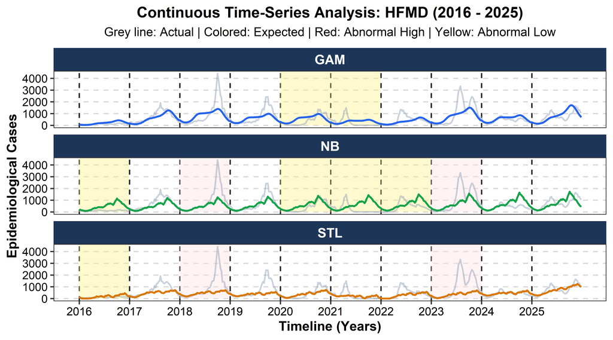

```r
plot_elite_timeseries(res_m2$plot_data, "HFMD")
```